# exercise-12

2024-04-10

### Preliminaries

- Using the {tidyverse} read_tsv() function, load the “Mammal_lifehistories_v2.txt” dataset from this [URL](https://raw.githubusercontent.com/difiore/ada-2024-datasets/main/Mammal_lifehistories_v2.txt) as a “tibble” named d. As discussed in class, this is dataset that compiles life history and other variables for over 1400 species of placental mammals from 17 different Orders.
- Do a bit of exploratory data analysis with this dataset, e.g., using the {skimr} package. Which of the variables are categorical and which are numeric?
  - Categorical variables: order, family, Genus, and species
  - Numeric variables: mass(g), gestation(mo), newborn(g), weaning(mo), wean mass(g), AFR(mo) max.life(mo), litter size, litters/year, refs

```r
# Load libraries
library(skimr)
library(tidyverse)
library(naniar)
```

```r
# Grab file
f <- "https://raw.githubusercontent.com/difiore/ada-2024-datasets/main/Mammal_lifehistories_v2.txt"
d <- read_tsv(f, col_names = TRUE)
skim (d)
```

Data summary

| Name | d |
| --- | --- |
| Number of rows | 1440 |
| Number of columns | 14 |
| _______________________ |  |
| Column type frequency: |  |
| character | 4 |
| numeric | 10 |
| ________________________ |  |
| Group variables | None |

**Variable type: character**

| skim_variable | n_missing | complete_rate | min | max | empty | n_unique | whitespace |
| --- | --- | --- | --- | --- | --- | --- | --- |
| order | 0 | 1 | 7 | 14 | 0 | 17 | 0 |
| family | 0 | 1 | 6 | 15 | 0 | 96 | 0 |
| Genus | 0 | 1 | 3 | 16 | 0 | 618 | 0 |
| species | 0 | 1 | 3 | 17 | 0 | 1191 | 0 |

**Variable type: numeric**

| skim_variable | n_missing | complete_rate | mean | sd | p0 | p25 | p50 | p75 | p100 | hist |
| --- | --- | --- | --- | --- | --- | --- | --- | --- | --- | --- |
| mass(g) | 0 | 1 | 3.835767e+05 | 5.055163e+06 | -999 | 50 | 403.02 | 7009.17 | 1.490000e+08 | ▇▁▁▁▁ |
| gestation(mo) | 0 | 1 | -2.872500e+02 | 4.553600e+02 | -999 | -999 | 1.05 | 4.50 | 2.146000e+01 | ▃▁▁▁▇ |
| newborn(g) | 0 | 1 | 6.703150e+03 | 9.091252e+04 | -999 | -999 | 2.65 | 98.00 | 2.250000e+06 | ▇▁▁▁▁ |
| weaning(mo) | 0 | 1 | -4.271700e+02 | 4.967100e+02 | -999 | -999 | 0.73 | 2.00 | 4.800000e+01 | ▆▁▁▁▇ |
| wean mass(g) | 0 | 1 | 1.604893e+04 | 5.036502e+05 | -999 | -999 | -999.00 | 10.00 | 1.907500e+07 | ▇▁▁▁▁ |
| AFR(mo) | 0 | 1 | -4.081200e+02 | 5.049700e+02 | -999 | -999 | 2.50 | 15.61 | 2.100000e+02 | ▆▁▁▁▇ |
| max. life(mo) | 0 | 1 | -4.902600e+02 | 6.153000e+02 | -999 | -999 | -999.00 | 147.25 | 1.368000e+03 | ▇▁▅▁▁ |
| litter size | 0 | 1 | -5.563000e+01 | 2.348800e+02 | -999 | 1 | 2.27 | 3.84 | 1.418000e+01 | ▁▁▁▁▇ |
| litters/year | 0 | 1 | -4.771400e+02 | 5.000300e+02 | -999 | -999 | 0.38 | 1.15 | 7.500000e+00 | ▇▁▁▁▇ |
| refs | 0 | 1 | 1.054762e+12 | 3.619709e+13 | 1 | 116 | 1229.00 | 1242249.75 | 1.368101e+15 | ▇▁▁▁▁ |

```r
head(d)
```

```
## # A tibble: 6 × 14
##   order        family       Genus species `mass(g)` `gestation(mo)` `newborn(g)`
##   <chr>        <chr>        <chr> <chr>       <dbl>           <dbl>        <dbl>
## 1 Artiodactyla Antilocapri… Anti… americ…     45375            8.13        3246.
## 2 Artiodactyla Bovidae      Addax nasoma…    182375            9.39        5480
## 3 Artiodactyla Bovidae      Aepy… melamp…     41480            6.35        5093
## 4 Artiodactyla Bovidae      Alce… busela…    150000            7.9        10167.
## 5 Artiodactyla Bovidae      Ammo… clarkei     28500            6.8         -999
## 6 Artiodactyla Bovidae      Ammo… lervia      55500            5.08        3810
## # ℹ 7 more variables: `weaning(mo)` <dbl>, `wean mass(g)` <dbl>,
## #   `AFR(mo)` <dbl>, `max. life(mo)` <dbl>, `litter size` <dbl>,
## #   `litters/year` <dbl>, refs <dbl>
```

#### Step 1

- Replace all values of -999 (the authors’ code for missing data) with NA.

```r
# use replace_with_na_all() function from the {naniar} to replace -999 with NA.
d <- replace_with_na_all(data = d, condition = ~.x == -999.00)
```

#### Step 2

- Drop the variables **litter size** and **refs**.

```r
d <- d %>%
  dplyr::select(-c(`litter size`, refs))

# double check
glimpse(d) # litter size and refs are dropped
```

```
## Rows: 1,440
## Columns: 12
## $ order           <chr> "Artiodactyla", "Artiodactyla", "Artiodactyla", "Artio…
## $ family          <chr> "Antilocapridae", "Bovidae", "Bovidae", "Bovidae", "Bo…
## $ Genus           <chr> "Antilocapra", "Addax", "Aepyceros", "Alcelaphus", "Am…
## $ species         <chr> "americana", "nasomaculatus", "melampus", "buselaphus"…
## $ `mass(g)`       <dbl> 45375.0, 182375.0, 41480.0, 150000.0, 28500.0, 55500.0…
## $ `gestation(mo)` <dbl> 8.13, 9.39, 6.35, 7.90, 6.80, 5.08, 5.72, 5.50, 8.93, …
## $ `newborn(g)`    <dbl> 3246.36, 5480.00, 5093.00, 10166.67, NA, 3810.00, 3910…
## $ `weaning(mo)`   <dbl> 3.00, 6.50, 5.63, 6.50, NA, 4.00, 4.04, 2.13, 10.71, 6…
## $ `wean mass(g)`  <dbl> 8900, NA, 15900, NA, NA, NA, NA, NA, 157500, NA, NA, N…
## $ `AFR(mo)`       <dbl> 13.53, 27.27, 16.66, 23.02, NA, 14.89, 10.23, 20.13, 2…
## $ `max. life(mo)` <dbl> 142, 308, 213, 240, NA, 251, 228, 255, 300, 324, 300, …
## $ `litters/year`  <dbl> 1.00, 0.99, 0.95, NA, NA, 2.00, NA, 1.89, 1.00, 1.00, …
```

#### Step 3

- Log transform all of the other numeric variables

```r
# The mutate(across(where(is.numeric))) looks for variables that are numeric and log transforms. NOTE: Variable names DO NOT CHANGE. I am keeping them the same. Option to mutate(rename())
d <- d %>%
  mutate(across(where(is.numeric), ~log(.)))

glimpse(d)
```

```
## Rows: 1,440
## Columns: 12
## $ order           <chr> "Artiodactyla", "Artiodactyla", "Artiodactyla", "Artio…
## $ family          <chr> "Antilocapridae", "Bovidae", "Bovidae", "Bovidae", "Bo…
## $ Genus           <chr> "Antilocapra", "Addax", "Aepyceros", "Alcelaphus", "Am…
## $ species         <chr> "americana", "nasomaculatus", "melampus", "buselaphus"…
## $ `mass(g)`       <dbl> 10.722717, 12.113820, 10.632967, 11.918391, 10.257659,…
## $ `gestation(mo)` <dbl> 2.095561, 2.239645, 1.848455, 2.066863, 1.916923, 1.62…
## $ `newborn(g)`    <dbl> 8.085290, 8.608860, 8.535622, 9.226870, NA, 8.245384, …
## $ `weaning(mo)`   <dbl> 1.098612, 1.871802, 1.728109, 1.871802, NA, 1.386294, …
## $ `wean mass(g)`  <dbl> 9.093807, NA, 9.674074, NA, NA, NA, NA, NA, 11.967181,…
## $ `AFR(mo)`       <dbl> 2.604909, 3.305787, 2.813011, 3.136363, NA, 2.700690, …
## $ `max. life(mo)` <dbl> 4.955827, 5.730100, 5.361292, 5.480639, NA, 5.525453, …
## $ `litters/year`  <dbl> 0.00000000, -0.01005034, -0.05129329, NA, NA, 0.693147…
```

#### Step 4

```r
# Regress the selected variables on log transformed body mass, called mass(g)
# Must include na.action = na.include in order to include NA to make sure the matrix fits
m1 <- lm(`mass(g)` ~ `gestation(mo)`, data = d, na.action = na.exclude)
m2 <- lm(`mass(g)` ~ `weaning(mo)`, data = d, na.action = na.exclude)
m3 <- lm(`mass(g)` ~ `AFR(mo)`, data = d, na.action = na.exclude)
m4 <- lm(`mass(g)` ~ `max. life(mo)`, data = d, na.action = na.exclude)
m5 <- lm(`mass(g)` ~ `newborn(g)`, data = d, na.action = na.exclude)
m6 <- lm(`mass(g)` ~ `wean mass(g)`, data = d,  na.action = na.exclude)


# Need to call resid(). Doing m1$residuals did not include NA...
d <- d %>%
  mutate(
    relGest = resid(m1),
    relWean = resid(m2),
    relAFR = resid(m3),
    relLife = resid(m4),
    relNewbornMass = resid(m5),
    relWeaningMass = resid(m6)
  )
```

#### Step 5

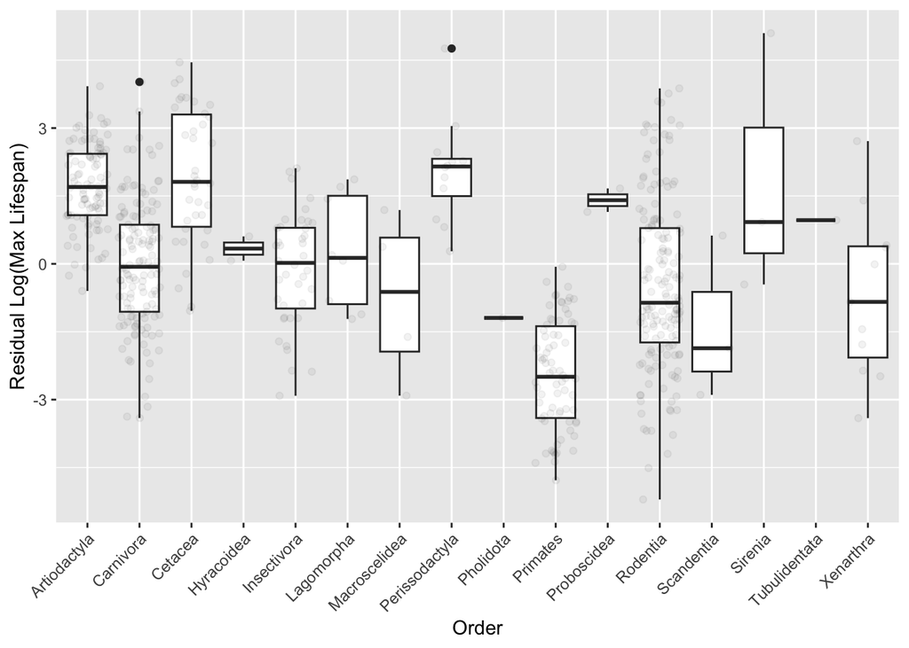

```r
# Plot: Residuals of max lifespan (relLife) in relation to Order
p_relLife <- ggplot(data = d %>% drop_na(relLife), aes(x = order, y = relLife)) +
  geom_boxplot() +
  geom_jitter(alpha = 0.05) + # makes the dots more transparent
  theme(axis.text.x = element_text(angle = 45, hjust = 1)) +
  xlab("Order") + ylab("Residual Log(Max Lifespan)")
p_relLife
```

```r
# To double check: max lifespan::order; use R's 5 number summary function fivenum() to definitively tell which orders have the highest max
relLife_5NumSum <- d %>%
  group_by(order) %>%
  summarise(n = n(),
            min = fivenum(relLife)[1],
            Q1 = fivenum(relLife)[2],
            median = fivenum(relLife)[3],
            Q3 = fivenum(relLife)[4],
            max = fivenum(relLife)[5])
relLife_5NumSum
```

```
## # A tibble: 17 × 7
##    order              n     min      Q1  median     Q3     max
##    <chr>          <int>   <dbl>   <dbl>   <dbl>  <dbl>   <dbl>
##  1 Artiodactyla     161 -0.599   1.07    1.70    2.43   3.93
##  2 Carnivora        197 -3.41   -1.06   -0.0650  0.865  4.02
##  3 Cetacea           55 -1.04    0.774   1.81    3.32   4.45
##  4 Dermoptera         2 NA      NA      NA      NA     NA
##  5 Hyracoidea         4  0.0686  0.0686  0.337   0.606  0.606
##  6 Insectivora       91 -2.91   -1.05    0.0214  0.803  2.11
##  7 Lagomorpha        42 -1.22   -0.965   0.132   1.57   1.87
##  8 Macroscelidea     10 -2.91   -2.26   -0.619   0.783  1.19
##  9 Perissodactyla    15  0.278   1.33    2.15    2.37   4.76
## 10 Pholidota          7 -1.19   -1.19   -1.19   -1.19  -1.19
## 11 Primates         156 -4.78   -3.42   -2.50   -1.35  -0.0641
## 12 Proboscidea        2  1.15    1.15    1.41    1.67   1.67
## 13 Rodentia         665 -5.21   -1.75   -0.859   0.795  3.88
## 14 Scandentia         7 -2.89   -2.38   -1.86   -0.620  0.625
## 15 Sirenia            5 -0.456   0.234   0.924   3.01   5.10
## 16 Tubulidentata      1  0.965   0.965   0.965   0.965  0.965
## 17 Xenarthra         20 -3.41   -2.07   -0.840   0.387  2.71
```

- Plot residuals of newborn mass (relNewbornMass) in relation to Order. Which mammalian orders have the have highest residual newborn mass?
  - Based on maximum values, the mammalian orders with the highest residual newborn mass: (1) Carnivora (2) Xenarthra (3) Artiodactyla
  - Based on median values, the mammalian orders with the highest residual newborn mass: (1) Carnivora (2) Tubulidentata (3) Proboscidea

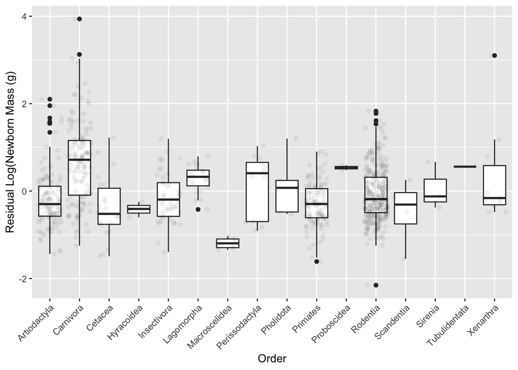

```r
# Plot: Residuals of newborn mass (relNewbornMass) in relation to Order
p_relNewbornMass <- ggplot(data = d %>% drop_na(relNewbornMass), aes(x = order, y = relNewbornMass)) +
  geom_boxplot() +
  geom_jitter(alpha = 0.05) + # makes the dots more transparent
  theme(axis.text.x = element_text(angle = 45, hjust = 1)) +
  xlab("Order") + ylab("Residual Log(Newborn Mass (g)")
p_relNewbornMass
```

```r
# It is difficult to tell what some of the maxes were on the graph, so using R's 5 number summary function fivenum() to definitively tell which orders have the highest max
relNewbornMass_5NumSum <- d %>%
  group_by(order) %>%
  summarise(n = n(),
            min = fivenum(relNewbornMass)[1],
            Q1 = fivenum(relNewbornMass)[2],
            median = fivenum(relNewbornMass)[3],
            Q3 = fivenum(relNewbornMass)[4],
            max = fivenum(relNewbornMass)[5])
relNewbornMass_5NumSum
```

```
## # A tibble: 17 × 7
##    order              n    min      Q1  median      Q3    max
##    <chr>          <int>  <dbl>   <dbl>   <dbl>   <dbl>  <dbl>
##  1 Artiodactyla     161 -1.44  -0.580  -0.297   0.117   2.10
##  2 Carnivora        197 -1.25  -0.0934  0.716   1.16    3.94
##  3 Cetacea           55 -1.49  -0.766  -0.521   0.147   1.22
##  4 Dermoptera         2 NA     NA      NA      NA      NA
##  5 Hyracoidea         4 -0.599 -0.504  -0.409  -0.328  -0.248
##  6 Insectivora       91 -1.39  -0.579  -0.194   0.193   1.19
##  7 Lagomorpha        42 -0.420  0.0928  0.327   0.480   0.793
##  8 Macroscelidea     10 -1.35  -1.31   -1.20   -1.08   -1.03
##  9 Perissodactyla    15 -0.905 -0.704   0.409   0.687   1.03
## 10 Pholidota          7 -0.524 -0.478   0.0744  0.244   1.20
## 11 Primates         156 -1.61  -0.610  -0.295   0.0553  0.903
## 12 Proboscidea        2  0.481  0.481   0.535   0.590   0.590
## 13 Rodentia         665 -2.15  -0.494  -0.184   0.316   1.83
## 14 Scandentia         7 -1.55  -1.02   -0.308   0.0609  0.252
## 15 Sirenia            5 -0.375 -0.248  -0.121   0.272   0.666
## 16 Tubulidentata      1  0.559  0.559   0.559   0.559   0.559
## 17 Xenarthra         20 -0.481 -0.331  -0.159   0.789   3.10
```

- Plot residuals of weaning mass (relWeaningMass) in relation to Order. Which mammalian orders have the have highest relative weaning mass?
  - Based on maximum values, mammalian orders with the highest relative weaning mass: (1) Carnivora, (2) Rodentia, (3) Lagomorpha
  - Based on median values, the mammalian orders with the highest relative weaning mass: (1) Xenarthra, (2) Tubulidentata, (3) Hyracoidea

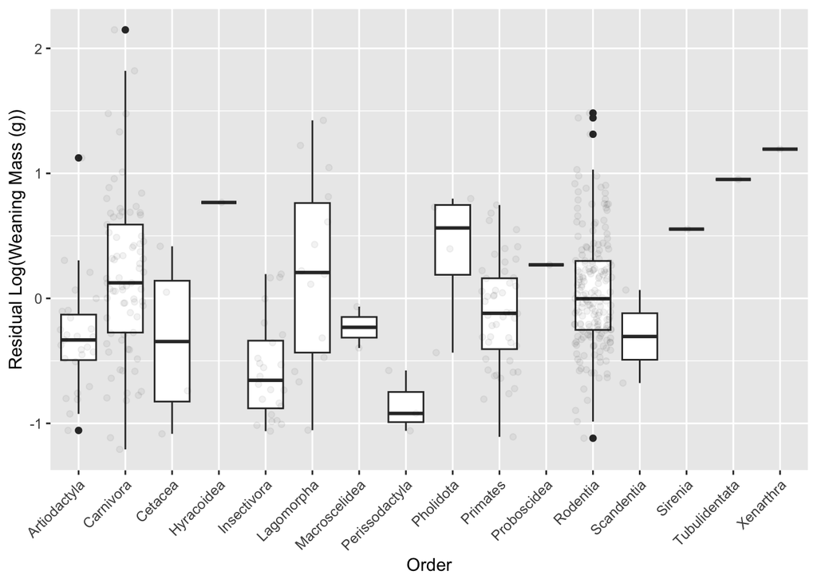

```r
# Plot: Residuals of weaning mass (relWeaningMass) in relation to Order
p_relWeaningMass <- ggplot(data = d %>% drop_na(relWeaningMass), aes(x = order, y = relWeaningMass)) +
  geom_boxplot() +
  geom_jitter(alpha = 0.05) + # makes the dots more transparent
  theme(axis.text.x = element_text(angle = 45, hjust = 1)) +
  xlab("Order") + ylab("Residual Log(Weaning Mass (g))")
p_relWeaningMass
```

```r
# To double check plots
relWeaningMass_5NumSum <- d %>%
  group_by(order) %>%
  summarise(n = n(),
            min = fivenum(relWeaningMass)[1],
            Q1 = fivenum(relWeaningMass)[2],
            median = fivenum(relWeaningMass)[3],
            Q3 = fivenum(relWeaningMass)[4],
            max = fivenum(relWeaningMass)[5])
relWeaningMass_5NumSum
```

```
## # A tibble: 17 × 7
##    order              n    min      Q1   median      Q3     max
##    <chr>          <int>  <dbl>   <dbl>    <dbl>   <dbl>   <dbl>
##  1 Artiodactyla     161 -1.06  -0.494  -0.333   -0.130   1.12
##  2 Carnivora        197 -1.21  -0.274   0.124    0.590   2.15
##  3 Cetacea           55 -1.08  -0.912  -0.345    0.233   0.417
##  4 Dermoptera         2 NA     NA      NA       NA      NA
##  5 Hyracoidea         4  0.767  0.767   0.767    0.767   0.767
##  6 Insectivora       91 -1.06  -0.896  -0.656   -0.323   0.194
##  7 Lagomorpha        42 -1.05  -0.473   0.207    0.813   1.42
##  8 Macroscelidea     10 -0.397 -0.397  -0.232   -0.0664 -0.0664
##  9 Perissodactyla    15 -1.06  -0.990  -0.920   -0.749  -0.577
## 10 Pholidota          7 -0.434 -0.0189  0.563    0.764   0.798
## 11 Primates         156 -1.11  -0.433  -0.119    0.162   0.747
## 12 Proboscidea        2  0.268  0.268   0.268    0.268   0.268
## 13 Rodentia         665 -1.12  -0.253  -0.00272  0.300   1.48
## 14 Scandentia         7 -0.677 -0.677  -0.305    0.0670  0.0670
## 15 Sirenia            5  0.554  0.554   0.554    0.554   0.554
## 16 Tubulidentata      1  0.951  0.951   0.951    0.951   0.951
## 17 Xenarthra         20  1.19   1.19    1.19     1.19    1.19
```

#### Step 6

- Run models and a model selection process to evaluate what (now log transformed) variables best predict each of the two response variables, max. life(mo) and AFR(mo), from the set of the following predictors: gestation(mo), newborn(g), weaning(mo), wean mass(g), litters/year, and overall body mass(g).
- For each of the two response variables, indicate what is the best model overall based on AICc and how many models have a delta AICc of 4 or less.
  - For `max. life(mo)` m4 is the best model which includes log transformed variables of `gestation(mo)`, `litters/year`, `mass(g)`,`weaning(mo)`. There are 5 models that have a delta AICc of 4 or less.
  - For `AFR(mo)`, the forward selection model has the log transformed variables of `litters/year`, `gestation(mo)`, `weaning(mo)`, and `wean mass(g)` as adding explanatory power. Reverse selection and AIC models have the log transformed variables of `litters/year`, `gestation(mo)`, `weaning(mo)`, and `mass(g)` as adding explanatory power. There are 7 models that have a delta AICc of 4 or less.
- What variables, if any, appear in all of this set of “top” models?
  - The variables that appear in all the sets are log transformed `gestation(mo)`, `litters/year`, and `weaning(mo)`. `mass(g)` appears in most models.
- Calculate and plot the model-averaged coefficients and their CIs across this set of top models.

#### First: max life

```r
# First, drop NAs
# Drop NAs for the response variable max. life(mo)
d_maxLife <- d %>%
  drop_na(`max. life(mo)`,`gestation(mo)`, `newborn(g)`, `weaning(mo)`, `wean mass(g)`, `litters/year`, `mass(g)`)

# Forward Selection Regression Modeling for max. life(mo)
# max. life(mo) null model
m0 <- lm(data = d_maxLife, `max. life(mo)` ~ 1)
add1(m0, scope = . ~ . + `gestation(mo)` + `newborn(g)` + `weaning(mo)` + `wean mass(g)` + `litters/year` + `mass(g)`, test = "F")
```

```
## Single term additions
##
## Model:
## `max. life(mo)` ~ 1
##                 Df Sum of Sq     RSS     AIC F value    Pr(>F)
## <none>                       177.452  -32.20
## `gestation(mo)`  1   122.169  55.283 -273.94  457.45 < 2.2e-16 ***
## `newborn(g)`     1   113.172  64.280 -242.43  364.44 < 2.2e-16 ***
## `weaning(mo)`    1    99.056  78.396 -200.94  261.55 < 2.2e-16 ***
## `wean mass(g)`   1   117.341  60.111 -256.44  404.08 < 2.2e-16 ***
## `litters/year`   1   100.053  77.398 -203.61  267.59 < 2.2e-16 ***
## `mass(g)`        1   116.049  61.402 -252.00  391.23 < 2.2e-16 ***
## ---
## Signif. codes:  0 '***' 0.001 '**' 0.01 '*' 0.05 '.' 0.1 ' ' 1
```

```r
# All values would add explanatory power, but gestation(mo) is associated with the highest new F statistic

m1 <- update(m0, formula = . ~ . + `gestation(mo)`)
summary(m1)
```

```
##
## Call:
## lm(formula = `max. life(mo)` ~ `gestation(mo)`, data = d_maxLife)
##
## Residuals:
##      Min       1Q   Median       3Q      Max
## -1.49203 -0.32056 -0.01956  0.37618  1.21758
##
## Coefficients:
##                 Estimate Std. Error t value Pr(>|t|)
## (Intercept)      4.24952    0.05134   82.77   <2e-16 ***
## `gestation(mo)`  0.79589    0.03721   21.39   <2e-16 ***
## ---
## Signif. codes:  0 '***' 0.001 '**' 0.01 '*' 0.05 '.' 0.1 ' ' 1
##
## Residual standard error: 0.5168 on 207 degrees of freedom
## Multiple R-squared:  0.6885, Adjusted R-squared:  0.687
## F-statistic: 457.4 on 1 and 207 DF,  p-value: < 2.2e-16
```

```r
add1(m1, scope = . ~ . + `gestation(mo)` + `newborn(g)` + `weaning(mo)` + `wean mass(g)` + `litters/year` + `mass(g)`, test = "F")
```

```
## Single term additions
##
## Model:
## `max. life(mo)` ~ `gestation(mo)`
##                Df Sum of Sq    RSS     AIC F value    Pr(>F)
## <none>                      55.283 -273.94
## `newborn(g)`    1    2.2088 53.074 -280.47  8.5731  0.003795 **
## `weaning(mo)`   1    5.5215 49.761 -293.94 22.8579 3.316e-06 ***
## `wean mass(g)`  1    5.4940 49.789 -293.82 22.7312 3.519e-06 ***
## `litters/year`  1    9.6219 45.661 -311.91 43.4095 3.639e-10 ***
## `mass(g)`       1    6.6254 48.657 -298.62 28.0498 3.024e-07 ***
## ---
## Signif. codes:  0 '***' 0.001 '**' 0.01 '*' 0.05 '.' 0.1 ' ' 1
```

```r
# All values would add explanatory power, but `litters/year` is associated with the highest new F statistic
m2 <- update(m1, formula = . ~ . + `litters/year`)
summary(m2)
```

```
##
## Call:
## lm(formula = `max. life(mo)` ~ `gestation(mo)` + `litters/year`,
##     data = d_maxLife)
##
## Residuals:
##     Min      1Q  Median      3Q     Max
## -1.5807 -0.2529 -0.0377  0.2986  1.1401
##
## Coefficients:
##                 Estimate Std. Error t value Pr(>|t|)
## (Intercept)      4.56267    0.06668  68.424  < 2e-16 ***
## `gestation(mo)`  0.57303    0.04789  11.966  < 2e-16 ***
## `litters/year`  -0.43397    0.06587  -6.589 3.64e-10 ***
## ---
## Signif. codes:  0 '***' 0.001 '**' 0.01 '*' 0.05 '.' 0.1 ' ' 1
##
## Residual standard error: 0.4708 on 206 degrees of freedom
## Multiple R-squared:  0.7427, Adjusted R-squared:  0.7402
## F-statistic: 297.3 on 2 and 206 DF,  p-value: < 2.2e-16
```

```r
add1(m2, scope = . ~ . + `gestation(mo)` + `newborn(g)` + `weaning(mo)` + `wean mass(g)` + `litters/year` + `mass(g)`, test = "F")
```

```
## Single term additions
##
## Model:
## `max. life(mo)` ~ `gestation(mo)` + `litters/year`
##                Df Sum of Sq    RSS     AIC F value    Pr(>F)
## <none>                      45.661 -311.91
## `newborn(g)`    1    1.6040 44.057 -317.38  7.4635 0.0068455 **
## `weaning(mo)`   1    0.7013 44.959 -313.14  3.1978 0.0752155 .
## `wean mass(g)`  1    2.6677 42.993 -322.49 12.7201 0.0004503 ***
## `mass(g)`       1    3.3026 42.358 -325.60 15.9834 8.915e-05 ***
## ---
## Signif. codes:  0 '***' 0.001 '**' 0.01 '*' 0.05 '.' 0.1 ' ' 1
```

```r
# Newborn(g), wean mass(g), and mass(g) are all significant. Mass(g) has highest F value
m3 <- update(m2, formula = . ~ . + `mass(g)`)
summary(m3)
```

```
##
## Call:
## lm(formula = `max. life(mo)` ~ `gestation(mo)` + `litters/year` +
##     `mass(g)`, data = d_maxLife)
##
## Residuals:
##      Min       1Q   Median       3Q      Max
## -1.51112 -0.23999 -0.01843  0.29693  1.11276
##
## Coefficients:
##                 Estimate Std. Error t value Pr(>|t|)
## (Intercept)      4.13652    0.12453  33.218  < 2e-16 ***
## `gestation(mo)`  0.38696    0.06560   5.898 1.50e-08 ***
## `litters/year`  -0.36413    0.06595  -5.521 1.01e-07 ***
## `mass(g)`        0.07594    0.01899   3.998 8.91e-05 ***
## ---
## Signif. codes:  0 '***' 0.001 '**' 0.01 '*' 0.05 '.' 0.1 ' ' 1
##
## Residual standard error: 0.4546 on 205 degrees of freedom
## Multiple R-squared:  0.7613, Adjusted R-squared:  0.7578
## F-statistic: 217.9 on 3 and 205 DF,  p-value: < 2.2e-16
```

```r
add1(m3, scope = . ~ . + `gestation(mo)` + `newborn(g)` + `weaning(mo)` + `wean mass(g)` + `litters/year` + `mass(g)`, test = "F")
```

```
## Single term additions
##
## Model:
## `max. life(mo)` ~ `gestation(mo)` + `litters/year` + `mass(g)`
##                Df Sum of Sq    RSS     AIC F value   Pr(>F)
## <none>                      42.358 -325.60
## `newborn(g)`    1   0.65041 41.708 -326.83  3.1813 0.075974 .
## `weaning(mo)`   1   1.46819 40.890 -330.97  7.3248 0.007377 **
## `wean mass(g)`  1   0.04196 42.316 -323.81  0.2023 0.653345
## ---
## Signif. codes:  0 '***' 0.001 '**' 0.01 '*' 0.05 '.' 0.1 ' ' 1
```

```r
# Only weaning(mo) is significant!
m4 <- update(m3, formula = . ~ . + `weaning(mo)`)
summary(m4)
```

```
##
## Call:
## lm(formula = `max. life(mo)` ~ `gestation(mo)` + `litters/year` +
##     `mass(g)` + `weaning(mo)`, data = d_maxLife)
##
## Residuals:
##      Min       1Q   Median       3Q      Max
## -1.46138 -0.25171 -0.03376  0.31187  1.04212
##
## Coefficients:
##                 Estimate Std. Error t value Pr(>|t|)
## (Intercept)      3.99891    0.13277  30.119  < 2e-16 ***
## `gestation(mo)`  0.29408    0.07316   4.019 8.21e-05 ***
## `litters/year`  -0.24745    0.07796  -3.174  0.00174 **
## `mass(g)`        0.08592    0.01907   4.506 1.11e-05 ***
## `weaning(mo)`    0.14218    0.05253   2.706  0.00738 **
## ---
## Signif. codes:  0 '***' 0.001 '**' 0.01 '*' 0.05 '.' 0.1 ' ' 1
##
## Residual standard error: 0.4477 on 204 degrees of freedom
## Multiple R-squared:  0.7696, Adjusted R-squared:  0.7651
## F-statistic: 170.3 on 4 and 204 DF,  p-value: < 2.2e-16
```

```r
add1(m4, scope = . ~ . + `gestation(mo)` + `newborn(g)` + `weaning(mo)` + `wean mass(g)` + `litters/year` + `mass(g)`, test = "F")
```

```
## Single term additions
##
## Model:
## `max. life(mo)` ~ `gestation(mo)` + `litters/year` + `mass(g)` +
##     `weaning(mo)`
##                Df Sum of Sq    RSS     AIC F value Pr(>F)
## <none>                      40.890 -330.97
## `newborn(g)`    1  0.308765 40.581 -330.56  1.5445 0.2154
## `wean mass(g)`  1  0.043789 40.846 -329.20  0.2176 0.6414
```

```r
# No more terms are significant! There are not any more predictors that would improve the explanatory power of the model.
# m4 is our best model for max life (mo)

# ...Using AIC to select
library(MASS)
# Start with the full model
m.full.MaxLife <- lm(data = d_maxLife, `max. life(mo)` ~ `gestation(mo)` + `newborn(g)` + `weaning(mo)` + `wean mass(g)` + `litters/year` + `mass(g)`)
s <- stepAIC(m.full.MaxLife, scope = .~., direction = "both")
```

```
## Start:  AIC=-328.57
## `max. life(mo)` ~ `gestation(mo)` + `newborn(g)` + `weaning(mo)` +
##     `wean mass(g)` + `litters/year` + `mass(g)`
##
##                   Df Sum of Sq    RSS     AIC
## - `wean mass(g)`   1   0.00271 40.581 -330.56
## - `newborn(g)`     1   0.26769 40.846 -329.20
## <none>                         40.579 -328.57
## - `mass(g)`        1   1.03563 41.614 -325.30
## - `weaning(mo)`    1   1.09864 41.677 -324.99
## - `litters/year`   1   1.63243 42.211 -322.33
## - `gestation(mo)`  1   2.91254 43.491 -316.08
##
## Step:  AIC=-330.56
## `max. life(mo)` ~ `gestation(mo)` + `newborn(g)` + `weaning(mo)` +
##     `litters/year` + `mass(g)`
##
##                   Df Sum of Sq    RSS     AIC
## - `newborn(g)`     1   0.30876 40.890 -330.97
## <none>                         40.581 -330.56
## + `wean mass(g)`   1   0.00271 40.579 -328.57
## - `weaning(mo)`    1   1.12655 41.708 -326.83
## - `litters/year`   1   1.65592 42.237 -324.20
## - `mass(g)`        1   1.98136 42.563 -322.59
## - `gestation(mo)`  1   2.91040 43.492 -318.08
##
## Step:  AIC=-330.97
## `max. life(mo)` ~ `gestation(mo)` + `weaning(mo)` + `litters/year` +
##     `mass(g)`
##
##                   Df Sum of Sq    RSS     AIC
## <none>                         40.890 -330.97
## + `newborn(g)`     1    0.3088 40.581 -330.56
## + `wean mass(g)`   1    0.0438 40.846 -329.20
## - `weaning(mo)`    1    1.4682 42.358 -325.60
## - `litters/year`   1    2.0193 42.909 -322.90
## - `gestation(mo)`  1    3.2383 44.128 -317.04
## - `mass(g)`        1    4.0694 44.959 -313.14
```

```r
summary(s)
```

```
##
## Call:
## lm(formula = `max. life(mo)` ~ `gestation(mo)` + `weaning(mo)` +
##     `litters/year` + `mass(g)`, data = d_maxLife)
##
## Residuals:
##      Min       1Q   Median       3Q      Max
## -1.46138 -0.25171 -0.03376  0.31187  1.04212
##
## Coefficients:
##                 Estimate Std. Error t value Pr(>|t|)
## (Intercept)      3.99891    0.13277  30.119  < 2e-16 ***
## `gestation(mo)`  0.29408    0.07316   4.019 8.21e-05 ***
## `weaning(mo)`    0.14218    0.05253   2.706  0.00738 **
## `litters/year`  -0.24745    0.07796  -3.174  0.00174 **
## `mass(g)`        0.08592    0.01907   4.506 1.11e-05 ***
## ---
## Signif. codes:  0 '***' 0.001 '**' 0.01 '*' 0.05 '.' 0.1 ' ' 1
##
## Residual standard error: 0.4477 on 204 degrees of freedom
## Multiple R-squared:  0.7696, Adjusted R-squared:  0.7651
## F-statistic: 170.3 on 4 and 204 DF,  p-value: < 2.2e-16
```

```r
# ... same as our m4 model: `gestation(mo)`, `weaning(mo)`, `litters/year`, and `mass(g)` add explanatory power to the model.

# Check delta AICc of 4 or less
library(AICcmodavg)
aictab(list(m0, m1, m2, m3, m4), c("m0", "m1", "m2", "m3", "m4"))
```

```
##
## Model selection based on AICc:
##
##    K   AICc Delta_AICc AICcWt Cum.Wt      LL
## m4 6 264.56       0.00   0.93   0.93 -126.07
## m3 5 269.81       5.25   0.07   1.00 -129.76
## m2 4 283.40      18.84   0.00   1.00 -137.60
## m1 3 321.29      56.73   0.00   1.00 -157.59
## m0 2 562.97     298.42   0.00   1.00 -279.46
```

#### Next: AFR

```r
# Repeat for AFR (mo)
# Drop NAs for the response variable AFR(mo)
d_AFR <- d %>%
  drop_na(`AFR(mo)`,`mass(g)`, `gestation(mo)`, `newborn(g)`, `weaning(mo)`, `wean mass(g)`, `litters/year`, )

# Create AFR null linear model
m0_AFR <- lm(data = d_AFR, `AFR(mo)` ~ 1)
add1(m0_AFR, scope = . ~ . + `gestation(mo)` + `newborn(g)` + `weaning(mo)` + `wean mass(g)` + `litters/year` + `mass(g)`, test = "F")
```

```
## Single term additions
##
## Model:
## `AFR(mo)` ~ 1
##                 Df Sum of Sq    RSS     AIC F value    Pr(>F)
## <none>                       391.65  106.12
## `gestation(mo)`  1    266.36 125.28 -192.78  557.03 < 2.2e-16 ***
## `newborn(g)`     1    233.51 158.14 -131.30  386.87 < 2.2e-16 ***
## `weaning(mo)`    1    244.14 147.51 -149.67  433.65 < 2.2e-16 ***
## `wean mass(g)`   1    244.96 146.69 -151.13  437.51 < 2.2e-16 ***
## `litters/year`   1    278.73 112.92 -220.22  646.75 < 2.2e-16 ***
## `mass(g)`        1    239.63 152.01 -141.72  413.02 < 2.2e-16 ***
## ---
## Signif. codes:  0 '***' 0.001 '**' 0.01 '*' 0.05 '.' 0.1 ' ' 1
```

```r
# Create AFR null linear model
m0_AFR <- lm(data = d_AFR, `AFR(mo)`~ 1)

# Add all variables
add1(m0_AFR, scope = . ~ . + `gestation(mo)` + `newborn(g)` + `weaning(mo)` + `wean mass(g)`+ `litters/year` + `mass(g)`, test = "F")
```

```
## Single term additions
##
## Model:
## `AFR(mo)` ~ 1
##                 Df Sum of Sq    RSS     AIC F value    Pr(>F)
## <none>                       391.65  106.12
## `gestation(mo)`  1    266.36 125.28 -192.78  557.03 < 2.2e-16 ***
## `newborn(g)`     1    233.51 158.14 -131.30  386.87 < 2.2e-16 ***
## `weaning(mo)`    1    244.14 147.51 -149.67  433.65 < 2.2e-16 ***
## `wean mass(g)`   1    244.96 146.69 -151.13  437.51 < 2.2e-16 ***
## `litters/year`   1    278.73 112.92 -220.22  646.75 < 2.2e-16 ***
## `mass(g)`        1    239.63 152.01 -141.72  413.02 < 2.2e-16 ***
## ---
## Signif. codes:  0 '***' 0.001 '**' 0.01 '*' 0.05 '.' 0.1 ' ' 1
```

```r
# All values would add explanatory power, but `litters/year` is associated with the highest new F statistic

m1_AFR <- update(m0_AFR, formula = . ~ . + `litters/year`)
summary(m1_AFR)
```

```
##
## Call:
## lm(formula = `AFR(mo)` ~ `litters/year`, data = d_AFR)
##
## Residuals:
##      Min       1Q   Median       3Q      Max
## -1.85135 -0.41485 -0.00401  0.37055  2.43903
##
## Coefficients:
##                Estimate Std. Error t value Pr(>|t|)
## (Intercept)     2.89976    0.04339   66.83   <2e-16 ***
## `litters/year` -1.41492    0.05564  -25.43   <2e-16 ***
## ---
## Signif. codes:  0 '***' 0.001 '**' 0.01 '*' 0.05 '.' 0.1 ' ' 1
##
## Residual standard error: 0.6565 on 262 degrees of freedom
## Multiple R-squared:  0.7117, Adjusted R-squared:  0.7106
## F-statistic: 646.7 on 1 and 262 DF,  p-value: < 2.2e-16
```

```r
add1(m1_AFR, scope = . ~ . + `gestation(mo)` + `newborn(g)` + `weaning(mo)` + `wean mass(g)`+ `litters/year` + `mass(g)`, test = "F")
```

```
## Single term additions
##
## Model:
## `AFR(mo)` ~ `litters/year`
##                 Df Sum of Sq     RSS     AIC F value    Pr(>F)
## <none>                       112.916 -220.22
## `gestation(mo)`  1    39.294  73.622 -331.13 139.303 < 2.2e-16 ***
## `newborn(g)`     1    32.477  80.438 -307.75 105.379 < 2.2e-16 ***
## `weaning(mo)`    1    17.618  95.298 -263.00  48.251 2.979e-11 ***
## `wean mass(g)`   1    31.485  81.430 -304.52 100.916 < 2.2e-16 ***
## `mass(g)`        1    28.882  84.034 -296.21  89.703 < 2.2e-16 ***
## ---
## Signif. codes:  0 '***' 0.001 '**' 0.01 '*' 0.05 '.' 0.1 ' ' 1
```

```r
# All values would add explanatory power, but `gestation(mo)` is associated with the highest new F statistic

m2_AFR <- update(m1_AFR, formula = . ~ . + `gestation(mo)`)
summary(m2_AFR)
```

```
##
## Call:
## lm(formula = `AFR(mo)` ~ `litters/year` + `gestation(mo)`, data = d_AFR)
##
## Residuals:
##      Min       1Q   Median       3Q      Max
## -1.39295 -0.32634 -0.01554  0.38231  1.85380
##
## Coefficients:
##                 Estimate Std. Error t value Pr(>|t|)
## (Intercept)      2.25983    0.06459   34.99   <2e-16 ***
## `litters/year`  -0.87144    0.06439  -13.53   <2e-16 ***
## `gestation(mo)`  0.56990    0.04829   11.80   <2e-16 ***
## ---
## Signif. codes:  0 '***' 0.001 '**' 0.01 '*' 0.05 '.' 0.1 ' ' 1
##
## Residual standard error: 0.5311 on 261 degrees of freedom
## Multiple R-squared:  0.812,  Adjusted R-squared:  0.8106
## F-statistic: 563.7 on 2 and 261 DF,  p-value: < 2.2e-16
```

```r
add1(m2_AFR, scope = . ~ . + `gestation(mo)` + `newborn(g)` + `weaning(mo)` + `wean mass(g)`+ `litters/year` + `mass(g)`, test = "F")
```

```
## Single term additions
##
## Model:
## `AFR(mo)` ~ `litters/year` + `gestation(mo)`
##                Df Sum of Sq    RSS     AIC F value  Pr(>F)
## <none>                      73.622 -331.13
## `newborn(g)`    1   0.71369 72.908 -331.70  2.5451 0.11185
## `weaning(mo)`   1   1.23838 72.383 -333.61  4.4482 0.03589 *
## `wean mass(g)`  1   1.52304 72.099 -334.65  5.4924 0.01985 *
## `mass(g)`       1   1.50422 72.117 -334.58  5.4231 0.02064 *
## ---
## Signif. codes:  0 '***' 0.001 '**' 0.01 '*' 0.05 '.' 0.1 ' ' 1
```

```r
# `weaning(mo)`, `wean mass(g)`, and `mass(g)` would add explanatory power, but `wean mass(g)` is associated with the highest new F statistic

m3_AFR <- update(m2_AFR, formula = . ~ . + `wean mass(g)`)
summary(m3_AFR)
```

```
##
## Call:
## lm(formula = `AFR(mo)` ~ `litters/year` + `gestation(mo)` + `wean mass(g)`,
##     data = d_AFR)
##
## Residuals:
##      Min       1Q   Median       3Q      Max
## -1.38130 -0.34898  0.00995  0.39575  1.78192
##
## Coefficients:
##                 Estimate Std. Error t value Pr(>|t|)
## (Intercept)      2.03326    0.11596  17.534  < 2e-16 ***
## `litters/year`  -0.84152    0.06511 -12.925  < 2e-16 ***
## `gestation(mo)`  0.43476    0.07495   5.801 1.91e-08 ***
## `wean mass(g)`   0.05377    0.02294   2.344   0.0199 *
## ---
## Signif. codes:  0 '***' 0.001 '**' 0.01 '*' 0.05 '.' 0.1 ' ' 1
##
## Residual standard error: 0.5266 on 260 degrees of freedom
## Multiple R-squared:  0.8159, Adjusted R-squared:  0.8138
## F-statistic: 384.1 on 3 and 260 DF,  p-value: < 2.2e-16
```

```r
add1(m3_AFR, scope = . ~ . + `gestation(mo)` + `newborn(g)` + `weaning(mo)` + `wean mass(g)`+ `litters/year` + `mass(g)`, test = "F")
```

```
## Single term additions
##
## Model:
## `AFR(mo)` ~ `litters/year` + `gestation(mo)` + `wean mass(g)`
##               Df Sum of Sq    RSS     AIC F value  Pr(>F)
## <none>                     72.099 -334.65
## `newborn(g)`   1   0.44927 71.649 -334.30  1.6240 0.20367
## `weaning(mo)`  1   1.80288 70.296 -339.33  6.6426 0.01051 *
## `mass(g)`      1   0.03965 72.059 -332.79  0.1425 0.70612
## ---
## Signif. codes:  0 '***' 0.001 '**' 0.01 '*' 0.05 '.' 0.1 ' ' 1
```

```r
# Only `weaning (mo)` is associated with the highest new F statistic
m4_AFR <- update(m3_AFR, formula = . ~ . + `weaning(mo)`)
summary(m4_AFR)
```

```
##
## Call:
## lm(formula = `AFR(mo)` ~ `litters/year` + `gestation(mo)` + `wean mass(g)` +
##     `weaning(mo)`, data = d_AFR)
##
## Residuals:
##      Min       1Q   Median       3Q      Max
## -1.34207 -0.34951  0.03252  0.38596  1.71839
##
## Coefficients:
##                 Estimate Std. Error t value Pr(>|t|)
## (Intercept)      1.91806    0.12312  15.578  < 2e-16 ***
## `litters/year`  -0.74028    0.07545  -9.812  < 2e-16 ***
## `gestation(mo)`  0.33438    0.08375   3.992 8.52e-05 ***
## `wean mass(g)`   0.06389    0.02304   2.773  0.00595 **
## `weaning(mo)`    0.14087    0.05466   2.577  0.01051 *
## ---
## Signif. codes:  0 '***' 0.001 '**' 0.01 '*' 0.05 '.' 0.1 ' ' 1
##
## Residual standard error: 0.521 on 259 degrees of freedom
## Multiple R-squared:  0.8205, Adjusted R-squared:  0.8177
## F-statistic:   296 on 4 and 259 DF,  p-value: < 2.2e-16
```

```r
add1(m4_AFR, scope = . ~ . + `gestation(mo)` + `newborn(g)` + `weaning(mo)` + `wean mass(g)`+ `litters/year` + `mass(g)`, test = "F")
```

```
## Single term additions
##
## Model:
## `AFR(mo)` ~ `litters/year` + `gestation(mo)` + `wean mass(g)` +
##     `weaning(mo)`
##              Df Sum of Sq    RSS     AIC F value Pr(>F)
## <none>                    70.296 -339.33
## `newborn(g)`  1   0.10143 70.194 -337.72  0.3728 0.5420
## `mass(g)`     1   0.10253 70.193 -337.72  0.3769 0.5398
```

```r
#Remaining variables do not add any more explanatory power.

# Same thing but backwards selection to double check
full_AFR <- lm(data = d_AFR, `AFR(mo)` ~ `gestation(mo)` + `newborn(g)` + `weaning(mo)` + `wean mass(g)` + `litters/year` + `mass(g)`)
summary(full_AFR)
```

```
##
## Call:
## lm(formula = `AFR(mo)` ~ `gestation(mo)` + `newborn(g)` + `weaning(mo)` +
##     `wean mass(g)` + `litters/year` + `mass(g)`, data = d_AFR)
##
## Residuals:
##      Min       1Q   Median       3Q      Max
## -1.27610 -0.36282  0.03122  0.37661  1.72945
##
## Coefficients:
##                 Estimate Std. Error t value Pr(>|t|)
## (Intercept)      1.77650    0.18352   9.680  < 2e-16 ***
## `gestation(mo)`  0.39649    0.10779   3.678 0.000286 ***
## `newborn(g)`    -0.05543    0.06529  -0.849 0.396731
## `weaning(mo)`    0.13148    0.05688   2.312 0.021592 *
## `wean mass(g)`   0.05424    0.07332   0.740 0.460129
## `litters/year`  -0.71737    0.07869  -9.117  < 2e-16 ***
## `mass(g)`        0.05226    0.06139   0.851 0.395415
## ---
## Signif. codes:  0 '***' 0.001 '**' 0.01 '*' 0.05 '.' 0.1 ' ' 1
##
## Residual standard error: 0.5219 on 257 degrees of freedom
## Multiple R-squared:  0.8213, Adjusted R-squared:  0.8171
## F-statistic: 196.8 on 6 and 257 DF,  p-value: < 2.2e-16
```

```r
drop1(full_AFR, test = "F")
```

```
## Single term deletions
##
## Model:
## `AFR(mo)` ~ `gestation(mo)` + `newborn(g)` + `weaning(mo)` +
##     `wean mass(g)` + `litters/year` + `mass(g)`
##                 Df Sum of Sq    RSS     AIC F value    Pr(>F)
## <none>                       69.997 -336.46
## `gestation(mo)`  1    3.6852 73.682 -324.91 13.5306 0.0002859 ***
## `newborn(g)`     1    0.1963 70.193 -337.72  0.7206 0.3967307
## `weaning(mo)`    1    1.4553 71.452 -333.03  5.3434 0.0215917 *
## `wean mass(g)`   1    0.1490 70.146 -337.90  0.5472 0.4601285
## `litters/year`   1   22.6366 92.634 -264.49 83.1123 < 2.2e-16 ***
## `mass(g)`        1    0.1974 70.194 -337.72  0.7247 0.3954149
## ---
## Signif. codes:  0 '***' 0.001 '**' 0.01 '*' 0.05 '.' 0.1 ' ' 1
```

```r
# `wean mass(g)`  has non-sig p-value, lowest F, and lowest increase in RSS; does not add any explanatory power

m1_AFR.drop <- update(full_AFR, . ~ . - `wean mass(g)`)
summary(m1_AFR.drop)
```

```
##
## Call:
## lm(formula = `AFR(mo)` ~ `gestation(mo)` + `newborn(g)` + `weaning(mo)` +
##     `litters/year` + `mass(g)`, data = d_AFR)
##
## Residuals:
##      Min       1Q   Median       3Q      Max
## -1.26465 -0.35319  0.02337  0.36704  1.73884
##
## Coefficients:
##                 Estimate Std. Error t value Pr(>|t|)
## (Intercept)      1.79759    0.18114   9.924  < 2e-16 ***
## `gestation(mo)`  0.39397    0.10764   3.660 0.000306 ***
## `newborn(g)`    -0.03372    0.05828  -0.579 0.563315
## `weaning(mo)`    0.13719    0.05630   2.437 0.015494 *
## `litters/year`  -0.72056    0.07850  -9.179  < 2e-16 ***
## `mass(g)`        0.08179    0.04660   1.755 0.080407 .
## ---
## Signif. codes:  0 '***' 0.001 '**' 0.01 '*' 0.05 '.' 0.1 ' ' 1
##
## Residual standard error: 0.5214 on 258 degrees of freedom
## Multiple R-squared:  0.8209, Adjusted R-squared:  0.8174
## F-statistic: 236.5 on 5 and 258 DF,  p-value: < 2.2e-16
```

```r
drop1(m1_AFR.drop, test = "F") # `newborn(g)` has non-sig p-value, lowest F, and lowest increase in RSS; does not add any explanatory power
```

```
## Single term deletions
##
## Model:
## `AFR(mo)` ~ `gestation(mo)` + `newborn(g)` + `weaning(mo)` +
##     `litters/year` + `mass(g)`
##                 Df Sum of Sq    RSS     AIC F value    Pr(>F)
## <none>                       70.146 -337.90
## `gestation(mo)`  1    3.6422 73.788 -326.53 13.3960 0.0003058 ***
## `newborn(g)`     1    0.0910 70.237 -339.56  0.3349 0.5633153
## `weaning(mo)`    1    1.6144 71.760 -333.89  5.9380 0.0154944 *
## `litters/year`   1   22.9076 93.054 -265.29 84.2552 < 2.2e-16 ***
## `mass(g)`        1    0.8376 70.984 -336.76  3.0808 0.0804066 .
## ---
## Signif. codes:  0 '***' 0.001 '**' 0.01 '*' 0.05 '.' 0.1 ' ' 1
```

```r
m2_AFR.drop <- update(m1_AFR.drop, . ~ . - `newborn(g)`)
summary(m2_AFR.drop) # all explanatory variables are significant, model 2 is best
```

```
##
## Call:
## lm(formula = `AFR(mo)` ~ `gestation(mo)` + `weaning(mo)` + `litters/year` +
##     `mass(g)`, data = d_AFR)
##
## Residuals:
##      Min       1Q   Median       3Q      Max
## -1.29820 -0.35036  0.01128  0.36368  1.72986
##
## Coefficients:
##                 Estimate Std. Error t value Pr(>|t|)
## (Intercept)      1.86557    0.13769  13.549  < 2e-16 ***
## `gestation(mo)`  0.35150    0.07864   4.470 1.17e-05 ***
## `weaning(mo)`    0.14440    0.05484   2.633  0.00897 **
## `litters/year`  -0.73119    0.07622  -9.593  < 2e-16 ***
## `mass(g)`        0.05757    0.02047   2.813  0.00528 **
## ---
## Signif. codes:  0 '***' 0.001 '**' 0.01 '*' 0.05 '.' 0.1 ' ' 1
##
## Residual standard error: 0.5208 on 259 degrees of freedom
## Multiple R-squared:  0.8207, Adjusted R-squared:  0.8179
## F-statistic: 296.3 on 4 and 259 DF,  p-value: < 2.2e-16
```

```r
aictab(list(m0_AFR, m1_AFR, m2_AFR, m3_AFR, m4_AFR), c("m0_AFR", "m1_AFR", "m2_AFR", "m3_AFR", "m4_AFR"))
```

```
##
## Model selection based on AICc:
##
##        K   AICc Delta_AICc AICcWt Cum.Wt      LL
## m4_AFR 6 412.19       0.00   0.89   0.89 -199.93
## m3_AFR 5 416.78       4.59   0.09   0.98 -203.28
## m2_AFR 4 420.22       8.03   0.02   1.00 -206.03
## m1_AFR 3 531.07     118.88   0.00   1.00 -262.49
## m0_AFR 2 857.37     445.18   0.00   1.00 -426.66
```

```r
detach(package:AICcmodavg)

# ...Using AIC to select
# Start with the full model
m.full.AFR <- lm(data = d_AFR, `AFR(mo)` ~ `gestation(mo)` + `newborn(g)` + `weaning(mo)` + `wean mass(g)` + `litters/year` + `mass(g)`, na.action = na.fail)
s <- stepAIC(m.full.AFR, scope = . ~ ., direction = "both")
```

```
## Start:  AIC=-336.46
## `AFR(mo)` ~ `gestation(mo)` + `newborn(g)` + `weaning(mo)` +
##     `wean mass(g)` + `litters/year` + `mass(g)`
##
##                   Df Sum of Sq    RSS     AIC
## - `wean mass(g)`   1    0.1490 70.146 -337.90
## - `newborn(g)`     1    0.1963 70.193 -337.72
## - `mass(g)`        1    0.1974 70.194 -337.72
## <none>                         69.997 -336.46
## - `weaning(mo)`    1    1.4553 71.452 -333.03
## - `gestation(mo)`  1    3.6852 73.682 -324.91
## - `litters/year`   1   22.6366 92.634 -264.49
##
## Step:  AIC=-337.9
## `AFR(mo)` ~ `gestation(mo)` + `newborn(g)` + `weaning(mo)` +
##     `litters/year` + `mass(g)`
##
##                   Df Sum of Sq    RSS     AIC
## - `newborn(g)`     1    0.0910 70.237 -339.56
## <none>                         70.146 -337.90
## - `mass(g)`        1    0.8376 70.984 -336.76
## + `wean mass(g)`   1    0.1490 69.997 -336.46
## - `weaning(mo)`    1    1.6144 71.760 -333.89
## - `gestation(mo)`  1    3.6422 73.788 -326.53
## - `litters/year`   1   22.9076 93.054 -265.29
##
## Step:  AIC=-339.56
## `AFR(mo)` ~ `gestation(mo)` + `weaning(mo)` + `litters/year` +
##     `mass(g)`
##
##                   Df Sum of Sq    RSS     AIC
## <none>                         70.237 -339.56
## + `newborn(g)`     1    0.0910 70.146 -337.90
## + `wean mass(g)`   1    0.0438 70.193 -337.72
## - `weaning(mo)`    1    1.8804 72.117 -334.58
## - `mass(g)`        1    2.1463 72.383 -333.61
## - `gestation(mo)`  1    5.4185 75.655 -321.94
## - `litters/year`   1   24.9554 95.192 -261.29
```

```r
summary(s)
```

```
##
## Call:
## lm(formula = `AFR(mo)` ~ `gestation(mo)` + `weaning(mo)` + `litters/year` +
##     `mass(g)`, data = d_AFR, na.action = na.fail)
##
## Residuals:
##      Min       1Q   Median       3Q      Max
## -1.29820 -0.35036  0.01128  0.36368  1.72986
##
## Coefficients:
##                 Estimate Std. Error t value Pr(>|t|)
## (Intercept)      1.86557    0.13769  13.549  < 2e-16 ***
## `gestation(mo)`  0.35150    0.07864   4.470 1.17e-05 ***
## `weaning(mo)`    0.14440    0.05484   2.633  0.00897 **
## `litters/year`  -0.73119    0.07622  -9.593  < 2e-16 ***
## `mass(g)`        0.05757    0.02047   2.813  0.00528 **
## ---
## Signif. codes:  0 '***' 0.001 '**' 0.01 '*' 0.05 '.' 0.1 ' ' 1
##
## Residual standard error: 0.5208 on 259 degrees of freedom
## Multiple R-squared:  0.8207, Adjusted R-squared:  0.8179
## F-statistic: 296.3 on 4 and 259 DF,  p-value: < 2.2e-16
```

```r
# Forward selection and reverse selection yielded different results. Reverse selection had the same variables as AIC. `litters/year`, `gestation(mo)`, and  `weaning (mo)` are the same across and add explanatory power to the model.
detach(package:MASS)
```

```r
# Using {MuMIn} package, we calculate the model-averaged coefficients and their CIs across this set of top models.
library(MuMIn)
# Max life (mo)
# Using full data set
m.full <- lm(data = d_maxLife, `max. life(mo)` ~ `gestation(mo)` + `newborn(g)` + `weaning(mo)` + `wean mass(g)` + `litters/year` + `mass(g)`, na.action = "na.fail")

# dredge from {MuMIn} explores subsets of a given global model in an automated way.
mods <- dredge(m.full)
```

```
## Fixed term is "(Intercept)"
```

```r
# number of models of delta AICc of 4 of less
(mods_delta <- subset(mods, delta <= 4))
```

```
## Global model call: lm(formula = `max. life(mo)` ~ `gestation(mo)` + `newborn(g)` +
##     `weaning(mo)` + `wean mass(g)` + `litters/year` + `mass(g)`,
##     data = d_maxLife, na.action = "na.fail")
## ---
## Model selection table
##    (Int) `gst(mo)` `ltt/yer` `mss(g)` `nwb(g)` `wenmss(g)` `wnn(mo)` df
## 40 3.999    0.2941   -0.2474  0.08592                         0.1422  6
## 48 3.865    0.3765   -0.2284  0.13260 -0.06478                0.1276  7
## 56 3.989    0.3077   -0.2470  0.10960            -0.028680    0.1423  7
## 64 3.862    0.3767   -0.2276  0.12830 -0.06792    0.008042    0.1269  8
## 52 4.111    0.2894   -0.2669                      0.087700    0.1346  6
##      logLik  AICc delta weight
## 40 -126.072 264.6  0.00  0.394
## 48 -125.280 265.1  0.56  0.298
## 56 -125.960 266.5  1.92  0.151
## 64 -125.273 267.3  2.71  0.102
## 52 -128.045 268.5  3.95  0.055
## Models ranked by AICc(x)
```

```r
# dredge() does not actually store the model results; use model.avg() function returns a “summary.averaging” object.
# average beta coefficients for models in the 95% confidence set, i.e., for cumulative AIC weights up to 95%:
(mods.avg <- summary(model.avg(mods, subset = delta <= 4, fit = TRUE)))
```

```
##
## Call:
## model.avg(object = get.models(object = mods, subset = delta <=
##     4))
##
## Component model call:
## lm(formula = `max. life(mo)` ~ <5 unique rhs>, data = d_maxLife,
##      na.action = na.fail)
##
## Component models:
##        df  logLik   AICc delta weight
## 1236    6 -126.07 264.56  0.00   0.39
## 12346   7 -125.28 265.12  0.56   0.30
## 12356   7 -125.96 266.48  1.92   0.15
## 123456  8 -125.27 267.27  2.71   0.10
## 1256    6 -128.05 268.51  3.95   0.05
##
## Term codes:
## `gestation(mo)`  `litters/year`       `mass(g)`    `newborn(g)`  `wean mass(g)`
##               1               2               3               4               5
##   `weaning(mo)`
##               6
##
## Model-averaged coefficients:
## (full average)
##                  Estimate Std. Error Adjusted SE z value Pr(>|z|)
## (Intercept)      3.949706   0.166665    0.167466  23.585  < 2e-16 ***
## `gestation(mo)`  0.328869   0.093972    0.094438   3.482 0.000497 ***
## `litters/year`  -0.240736   0.079388    0.079854   3.015 0.002572 **
## `mass(g)`        0.103022   0.049693    0.049867   2.066 0.038835 *
## `weaning(mo)`    0.135875   0.053586    0.053901   2.521 0.011708 *
## `newborn(g)`    -0.026237   0.046859    0.047008   0.558 0.576748
## `wean mass(g)`   0.001288   0.040439    0.040600   0.032 0.974699
##
## (conditional average)
##                  Estimate Std. Error Adjusted SE z value Pr(>|z|)
## (Intercept)      3.949706   0.166665    0.167466  23.585  < 2e-16 ***
## `gestation(mo)`  0.328869   0.093972    0.094438   3.482 0.000497 ***
## `litters/year`  -0.240736   0.079388    0.079854   3.015 0.002572 **
## `mass(g)`        0.108990   0.044295    0.044501   2.449 0.014320 *
## `weaning(mo)`    0.135875   0.053586    0.053901   2.521 0.011708 *
## `newborn(g)`    -0.065577   0.053928    0.054252   1.209 0.226761
## `wean mass(g)`   0.004185   0.072820    0.073111   0.057 0.954353
## ---
## Signif. codes:  0 '***' 0.001 '**' 0.01 '*' 0.05 '.' 0.1 ' ' 1
```

```r
mods.avg$msTable
```

```
##        df    logLik     AICc     delta    weight
## 1236    6 -126.0718 264.5595 0.0000000 0.3940678
## 12346   7 -125.2797 265.1167 0.5572036 0.2982467
## 12356   7 -125.9598 266.4769 1.9174343 0.1510794
## 123456  8 -125.2727 267.2655 2.7060124 0.1018516
## 1256    6 -128.0455 268.5068 3.9473269 0.0547545
```

```r
#use the confint() function for confidence intervals for the averaged average beta coefficients for models in the 95% CI set
confint(mods.avg)
```

```
##                       2.5 %      97.5 %
## (Intercept)      3.62147891  4.27793347
## `gestation(mo)`  0.14377472  0.51396308
## `litters/year`  -0.39724571 -0.08422565
## `mass(g)`        0.02176916  0.19621043
## `weaning(mo)`    0.03023157  0.24151902
## `newborn(g)`    -0.17190901  0.04075518
## `wean mass(g)`  -0.13911025  0.14748030
```

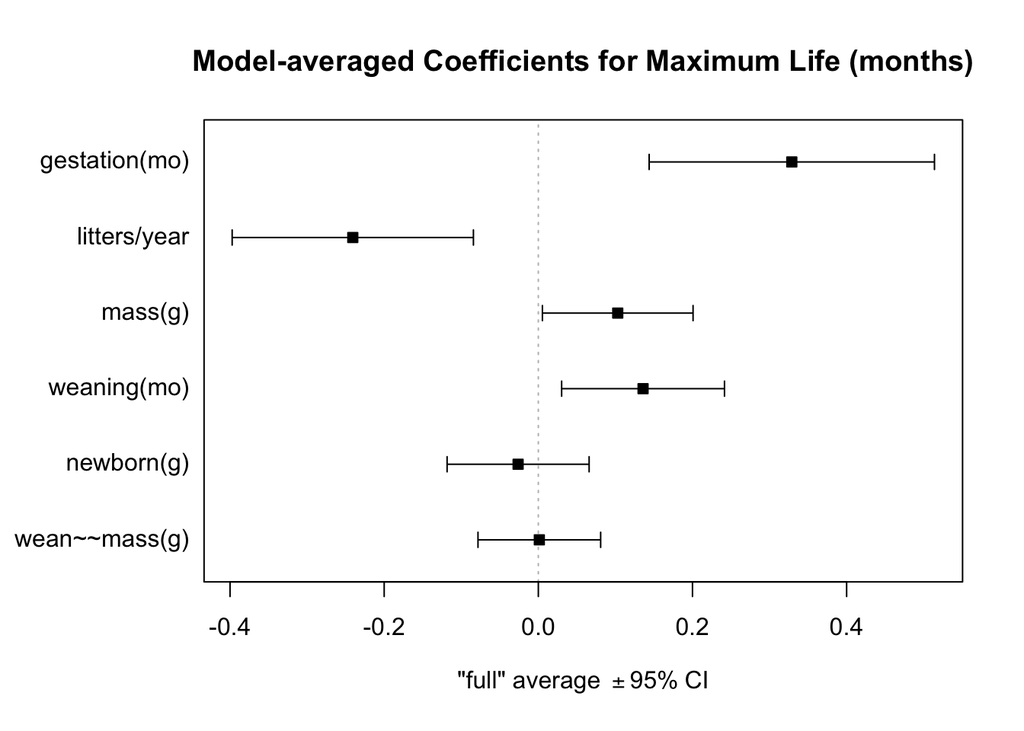

```r
# Using {MuMIn} package, we can also plot this
plot(mods.avg, full = TRUE, intercept = FALSE, main = "Model-averaged Coefficients for Maximum Life (months)")
```

```r
# Age at first reproduction (AFR)
m.full <- lm(data = d_AFR, `AFR(mo)` ~ `gestation(mo)` + `newborn(g)` + `weaning(mo)` + `wean mass(g)` + `litters/year` + `mass(g)`, na.action = "na.fail")

# dredge from {MuMIn}
mods <- dredge(m.full)
```

```
## Fixed term is "(Intercept)"
```

```r
# number of models of delta AICc of 4 of less
(mods_delta <- subset(mods, delta <= 4))
```

```
## Global model call: lm(formula = `AFR(mo)` ~ `gestation(mo)` + `newborn(g)` + `weaning(mo)` +
##     `wean mass(g)` + `litters/year` + `mass(g)`, data = d_AFR,
##     na.action = "na.fail")
## ---
## Model selection table
##    (Int) `gst(mo)` `ltt/yer` `mss(g)` `nwb(g)` `wenmss(g)` `wnn(mo)` df
## 40 1.866    0.3515   -0.7312  0.05757                         0.1444  6
## 52 1.918    0.3344   -0.7403                       0.06389    0.1409  6
## 48 1.798    0.3940   -0.7206  0.08179 -0.03372                0.1372  7
## 56 1.877    0.3395   -0.7330  0.03572              0.02627    0.1439  7
## 60 1.863    0.3716   -0.7320          -0.03779     0.09483    0.1315  7
## 44 2.075    0.3214   -0.7666           0.05815                0.1488  6
## 64 1.777    0.3965   -0.7174  0.05226 -0.05543     0.05424    0.1315  8
##      logLik  AICc delta weight
## 40 -199.822 412.0  0.00  0.286
## 52 -199.932 412.2  0.22  0.256
## 48 -199.651 413.7  1.77  0.118
## 56 -199.740 413.9  1.95  0.108
## 60 -199.742 413.9  1.95  0.108
## 44 -201.218 414.8  2.79  0.071
## 64 -199.370 415.3  3.33  0.054
## Models ranked by AICc(x)
```

```r
# average coefficients for top models where delta.aicc <= 4
(mods.avg <- summary(model.avg(mods, subset = delta <= 4, fit = TRUE)))
```

```
##
## Call:
## model.avg(object = get.models(object = mods, subset = delta <=
##     4))
##
## Component model call:
## lm(formula = `AFR(mo)` ~ <7 unique rhs>, data = d_AFR, na.action =
##      na.fail)
##
## Component models:
##        df  logLik   AICc delta weight
## 1236    6 -199.82 411.97  0.00   0.29
## 1256    6 -199.93 412.19  0.22   0.26
## 12346   7 -199.65 413.74  1.77   0.12
## 12356   7 -199.74 413.92  1.95   0.11
## 12456   7 -199.74 413.92  1.95   0.11
## 1246    6 -201.22 414.76  2.79   0.07
## 123456  8 -199.37 415.30  3.33   0.05
##
## Term codes:
## `gestation(mo)`  `litters/year`       `mass(g)`    `newborn(g)`  `wean mass(g)`
##               1               2               3               4               5
##   `weaning(mo)`
##               6
##
## Model-averaged coefficients:
## (full average)
##                  Estimate Std. Error Adjusted SE z value Pr(>|z|)
## (Intercept)      1.881883   0.157221    0.157826  11.924  < 2e-16 ***
## `gestation(mo)`  0.353306   0.093289    0.093702   3.771 0.000163 ***
## `litters/year`  -0.734295   0.077192    0.077547   9.469  < 2e-16 ***
## `mass(g)`        0.032778   0.043499    0.043601   0.752 0.452196
## `weaning(mo)`    0.140805   0.055623    0.055883   2.520 0.011747 *
## `wean mass(g)`   0.032328   0.049236    0.049353   0.655 0.512445
## `newborn(g)`    -0.006927   0.041658    0.041781   0.166 0.868313
##
## (conditional average)
##                 Estimate Std. Error Adjusted SE z value Pr(>|z|)
## (Intercept)      1.88188    0.15722     0.15783  11.924  < 2e-16 ***
## `gestation(mo)`  0.35331    0.09329     0.09370   3.771 0.000163 ***
## `litters/year`  -0.73429    0.07719     0.07755   9.469  < 2e-16 ***
## `mass(g)`        0.05795    0.04343     0.04362   1.329 0.183972
## `weaning(mo)`    0.14081    0.05562     0.05588   2.520 0.011747 *
## `wean mass(g)`   0.06151    0.05308     0.05329   1.154 0.248332
## `newborn(g)`    -0.01977    0.06854     0.06875   0.287 0.773741
## ---
## Signif. codes:  0 '***' 0.001 '**' 0.01 '*' 0.05 '.' 0.1 ' ' 1
```

```r
mods.avg$msTable
```

```
##        df    logLik     AICc     delta     weight
## 1236    6 -199.8221 411.9710 0.0000000 0.28569102
## 1256    6 -199.9324 412.1916 0.2205931 0.25585589
## 12346   7 -199.6509 413.7392 1.7682251 0.11801342
## 12356   7 -199.7397 413.9169 1.9459034 0.10798142
## 12456   7 -199.7418 413.9210 1.9500329 0.10775869
## 1246    6 -201.2178 414.7624 2.7913831 0.07075473
## 123456  8 -199.3701 415.3049 3.3338976 0.05394484
```

```r
#use the confint() function for confidence intervals for the averaged average beta coefficients for models in the 95% CI set
confint(mods.avg)
```

```
##                       2.5 %     97.5 %
## (Intercept)      1.57255043  2.1912166
## `gestation(mo)`  0.16965399  0.5369572
## `litters/year`  -0.88628517 -0.5823047
## `mass(g)`       -0.02753636  0.1434341
## `weaning(mo)`    0.03127700  0.2503339
## `wean mass(g)`  -0.04292452  0.1659521
## `newborn(g)`    -0.15452137  0.1149898
```

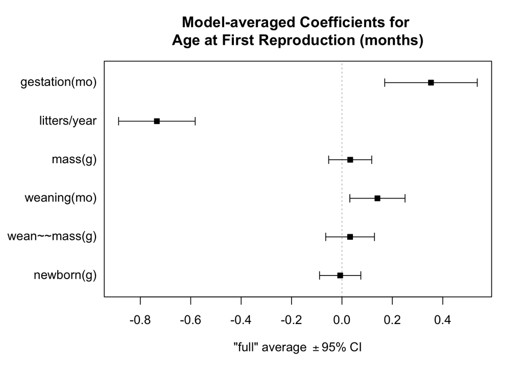

```r
# Using {MuMIn} package, we can also plot this
plot(mods.avg, full = TRUE, intercept = FALSE, main = "Model-averaged Coefficients for \nAge at First Reproduction (months)")
```